# W1 STAT5003 RMD

Victor Z. Nygaard, vnyg7406

Last compiled on 28. januar, 2023

Having loaded in `tidyverse` in the setup chunk, we start the assignment.

## 2. File I/O:

We load in the data, and assign it:

```r
cereal <- read.csv("../Data/Cereal.csv")
head(cereal) #Glimpse into data - 2.2a
```

```
##                        name mfr type calories protein fat sodium fiber carbo
## 1                 100%_Bran   N    C       70       4   1    130  10.0   5.0
## 2         100%_Natural_Bran   Q    C      120       3   5     15   2.0   8.0
## 3                  All-Bran   K    C       70       4   1    260   9.0   7.0
## 4 All-Bran_with_Extra_Fiber   K    C       50       4   0    140  14.0   8.0
## 5            Almond_Delight   R    C      110       2   2    200   1.0  14.0
## 6   Apple_Cinnamon_Cheerios   G    C      110       2   2    180   1.5  10.5
##   sugars potass vitamins shelf weight cups   rating
## 1      6    280       25     3      1 0.33 68.40297
## 2      8    135        0     3      1 1.00 33.98368
## 3      5    320       25     3      1 0.33 59.42551
## 4      0    330       25     3      1 0.50 93.70491
## 5      8     -1       25     3      1 0.75 34.38484
## 6     10     70       25     1      1 0.75 29.50954
```

```r
class(cereal) # 2.2a
```

```
## [1] "data.frame"
```

```r
typeof(cereal)
```

```
## [1] "list"
```

We can find the column names of `cereal`, respectively, the number of rows and columns as

```r
# - 2.2b
names(cereal)
```

```
##  [1] "name"     "mfr"      "type"     "calories" "protein"  "fat"
##  [7] "sodium"   "fiber"    "carbo"    "sugars"   "potass"   "vitamins"
## [13] "shelf"    "weight"   "cups"     "rating"
```

```r
dim(cereal)
```

```
## [1] 77 16
```

We may extract the `calories` column using the following commands, here with the `results = "hide"` option enabled for the chunk, so as not to print excesive output.

```r
#2.2c)
cereal$calories
cereal[["calories"]]
```

Below are commands that might be used to extract the first ten rows of `cereal`, respectively to assign all `mfr == "K"` rows of `cereal` to `Kellogs`. We once again hide results.

```r
#2.2d), 2.2e)
cereal[1:10,]
Kelloggs <- cereal %>% subset(mfr == "K")
```

As according to 2.3, we load in the data-set once again, now with an addition argument. Noting that the `head` command also specifies the data types of the different columns, the following commands confirms the results of the `stringsAsFactor` conversion, as well as showcasing the levels of each of `mfr` and `type`.

```r
#2.3
cereal <- read.csv("../Data/Cereal.csv", stringsAsFactors = T)
head(cereal)
```

```
##                        name mfr type calories protein fat sodium fiber carbo
## 1                 100%_Bran   N    C       70       4   1    130  10.0   5.0
## 2         100%_Natural_Bran   Q    C      120       3   5     15   2.0   8.0
## 3                  All-Bran   K    C       70       4   1    260   9.0   7.0
## 4 All-Bran_with_Extra_Fiber   K    C       50       4   0    140  14.0   8.0
## 5            Almond_Delight   R    C      110       2   2    200   1.0  14.0
## 6   Apple_Cinnamon_Cheerios   G    C      110       2   2    180   1.5  10.5
##   sugars potass vitamins shelf weight cups   rating
## 1      6    280       25     3      1 0.33 68.40297
## 2      8    135        0     3      1 1.00 33.98368
## 3      5    320       25     3      1 0.33 59.42551
## 4      0    330       25     3      1 0.50 93.70491
## 5      8     -1       25     3      1 0.75 34.38484
## 6     10     70       25     1      1 0.75 29.50954
```

```r
class(cereal$mfr)
```

```
## [1] "factor"
```

```r
class(cereal$type)
```

```
## [1] "factor"
```

```r
levels(cereal$mfr)
```

```
## [1] "A" "G" "K" "N" "P" "Q" "R"
```

```r
levels(cereal$type)
```

```
## [1] "C" "H"
```

For exercise 2.4 we extract the requested column, assign it, check its length (the number of rows of `cereal`), extract the 5th and 10th element from `.calories` as well as adding the element `25` to `cereal.calories`.

```r
#2.4
cereal.calories <- cereal$calories
length(cereal.calories)
```

```
## [1] 77
```

```r
c(cereal.calories[5], cereal.calories[10])
```

```
## [1] 110  90
```

```r
cereal.calories <- c(cereal.calories,25)
```

For 2.5, we may test the datatypes of the Matrix-coersed `cereal` data, respectively extract all but the `mfr`, `type` and `name`-columns using `dplyr`’s `select` command. Note the `::`-specification, required in order to avoid a conflict with `MASS::select`. Having taken out the requested columns, we see that the result is now numeric (a `double`).

```r
#2.5
typeof(as.matrix(cereal))
```

```
## [1] "character"
```

```r
typeof(as.matrix(cereal %>% dplyr::select(-mfr, -type, -name)))
```

```
## [1] "double"
```

For 3.1, `summary` lets us extract many useful summary statistics about data. In particular, quantile ranges.

```r
#3.1
#attributes(summary(cereal))
summary(cereal)
```

```
##                         name    mfr    type      calories        protein
##  100%_Bran                : 1   A: 1   C:74   Min.   : 50.0   Min.   :1.000
##  100%_Natural_Bran        : 1   G:22   H: 3   1st Qu.:100.0   1st Qu.:2.000
##  All-Bran                 : 1   K:23          Median :110.0   Median :3.000
##  All-Bran_with_Extra_Fiber: 1   N: 6          Mean   :106.9   Mean   :2.545
##  Almond_Delight           : 1   P: 9          3rd Qu.:110.0   3rd Qu.:3.000
##  Apple_Cinnamon_Cheerios  : 1   Q: 8          Max.   :160.0   Max.   :6.000
##  (Other)                  :71   R: 8
##       fat            sodium          fiber            carbo
##  Min.   :0.000   Min.   :  0.0   Min.   : 0.000   Min.   :-1.0
##  1st Qu.:0.000   1st Qu.:130.0   1st Qu.: 1.000   1st Qu.:12.0
##  Median :1.000   Median :180.0   Median : 2.000   Median :14.0
##  Mean   :1.013   Mean   :159.7   Mean   : 2.152   Mean   :14.6
##  3rd Qu.:2.000   3rd Qu.:210.0   3rd Qu.: 3.000   3rd Qu.:17.0
##  Max.   :5.000   Max.   :320.0   Max.   :14.000   Max.   :23.0
##
##      sugars           potass          vitamins          shelf
##  Min.   :-1.000   Min.   : -1.00   Min.   :  0.00   Min.   :1.000
##  1st Qu.: 3.000   1st Qu.: 40.00   1st Qu.: 25.00   1st Qu.:1.000
##  Median : 7.000   Median : 90.00   Median : 25.00   Median :2.000
##  Mean   : 6.922   Mean   : 96.08   Mean   : 28.25   Mean   :2.208
##  3rd Qu.:11.000   3rd Qu.:120.00   3rd Qu.: 25.00   3rd Qu.:3.000
##  Max.   :15.000   Max.   :330.00   Max.   :100.00   Max.   :3.000
##
##      weight          cups           rating
##  Min.   :0.50   Min.   :0.250   Min.   :18.04
##  1st Qu.:1.00   1st Qu.:0.670   1st Qu.:33.17
##  Median :1.00   Median :0.750   Median :40.40
##  Mean   :1.03   Mean   :0.821   Mean   :42.67
##  3rd Qu.:1.00   3rd Qu.:1.000   3rd Qu.:50.83
##  Max.   :1.50   Max.   :1.500   Max.   :93.70
##
```

For 3.2, we may use the following commands to find find the max, min, standard deviation and mean of `cereal$sodium`, as well as the mean of `sodium` as grouped by each `mfr`.

```r
#3.2
max(cereal$sodium)
```

```
## [1] 320
```

```r
min(cereal$sodium)
```

```
## [1] 0
```

```r
sd(cereal$sodium)
```

```
## [1] 83.8323
```

```r
mean(cereal$sodium)
```

```
## [1] 159.6753
```

```r
tapply(cereal$sodium, cereal$mfr, mean)
```

```
##        A        G        K        N        P        Q        R
##   0.0000 200.4545 174.7826  37.5000 146.1111  92.5000 198.1250
```

Using standard -graphics, we may provide a boxplot of `sodium`, as well as a scatterplot of `calories` against `sodium`. Here placed next to each other courtesy of `par(mfrow)`

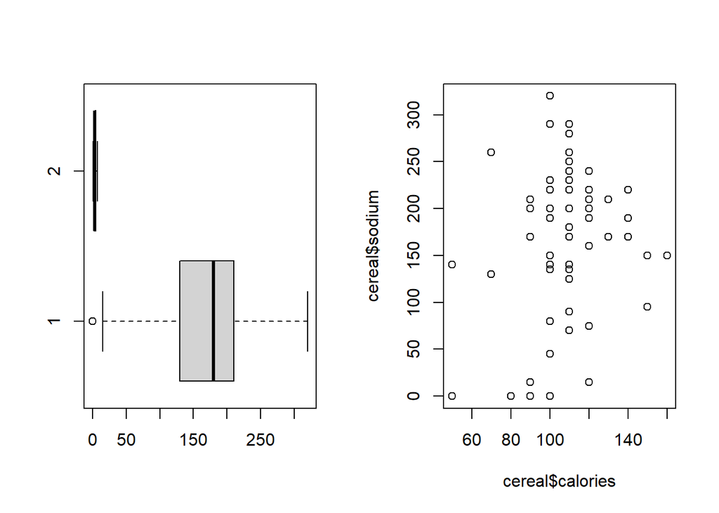

```r
#Exercise 4
par(mfrow=(c(1,2)))
boxplot(cereal$sodium, cereal$mfr, horizontal = T)
plot(cereal$calories, cereal$sodium)
```

For exercise $5$ we may finally write the `Kellogs`-data to a .csv file as follows.

```r
write.csv(Kelloggs, "kelloggs.csv")
```